# EI-EP09-respuesta-equipo-7

Branco García Santana

2023-11-16

# Equipo 7

### Datos

```r
datos <- read.csv2("EP09 Datos.csv", sep = ";")
```

1. Definir la semilla a utilizar, que corresponde a los últimos cuatro dígitos del RUN (sin considerar el dígito verificador) del integrante de menor edad del equipo.

```r
set.seed(2122)
```

2. Seleccionar una muestra de 50 mujeres (si la semilla es un número par) o 50 hombres (si la semilla es impar).

```r
datos_m <- datos[datos$Gender == 0, ]
muestra_m = datos_m[sample(1:nrow(datos_m), size = 50),]
head(muestra_m)
```

```
##     Biacromial.diameter Biiliac.diameter Bitrochanteric.diameter Chest.depth
## 329                36.5             26.0                    30.7        15.9
## 315                38.2             30.0                    35.5        19.4
## 300                34.0             27.3                    32.2        19.0
## 470                38.9             28.5                    34.0        19.2
## 368                35.0             23.7                    29.0        15.4
## 427                35.3             23.3                    28.3        15.3
##     Chest.diameter Elbows.diameter Wrists.diameter Knees.diameter
## 329           26.8            12.1            10.3           17.0
## 315           26.7            12.6            10.8           19.5
## 300           24.2            12.9            10.6           17.9
## 470           27.5            13.3            10.3           19.1
## 368           23.6            11.5             9.6           16.6
## 427           24.7            12.4            10.2           17.1
##     Ankles.diameter Shoulder.Girth Chest.Girth Waist.Girth Navel.Girth
```

[output cut: 27 more lines]

3. Seleccionar de forma aleatoria ocho posibles variables predictoras.

```r
num_columnas = 8
predictores_a <- sample(names(muestra_m), num_columnas)
print(predictores_a)
```

```
## [1] "Knees.diameter"          "Bicep.Girth"
## [3] "Chest.diameter"          "Wrists.diameter"
## [5] "Elbows.diameter"         "Chest.depth"
## [7] "Bitrochanteric.diameter" "Navel.Girth"
```

### Modelo regresión lineal simple

4. Seleccionar, de las otras variables, una que el equipo considere que podría ser útil para predecir la variable Peso, justificando bien esta selección.

```r
# Primero obtenemos el nombre de todos los predictores que no sean los 8 seleccionados
predictores_completo <- names(muestra_m)
resto_predictores <- setdiff(predictores_completo, predictores_a)


getCor <- function(predictores, data){
  for (i in predictores) {
    cor_test <- cor.test(data$Weight, data[[i]], method = "pearson")
    cat("Coeficiente de correlación para", i, ":", cor_test$estimate, "\n")
  }
}

getCor(resto_predictores, muestra_m)
```

```
## Coeficiente de correlación para Biacromial.diameter : 0.5406709
## Coeficiente de correlación para Biiliac.diameter : 0.5184913
## Coeficiente de correlación para Ankles.diameter : 0.5491559
## Coeficiente de correlación para Shoulder.Girth : 0.7215236
## Coeficiente de correlación para Chest.Girth : 0.8588273
## Coeficiente de correlación para Waist.Girth : 0.8189292
## Coeficiente de correlación para Hip.Girth : 0.8906512
## Coeficiente de correlación para Thigh.Girth : 0.8205998
## Coeficiente de correlación para Forearm.Girth : 0.8135369
## Coeficiente de correlación para Knee.Girth : 0.8097562
## Coeficiente de correlación para Calf.Maximum.Girth : 0.7132519
## Coeficiente de correlación para Ankle.Minimum.Girth : 0.6305831
## Coeficiente de correlación para Wrist.Minimum.Girth : 0.8061946
## Coeficiente de correlación para Age : 0.1590878
## Coeficiente de correlación para Weight : 1
## Coeficiente de correlación para Height : 0.4389898
```

```
## Coeficiente de correlación para Gender : NA
```

A partir de los datos obtenidos tras realizar una prueba de correlación entre el resto de predictores y la variable de respuesta Peso, es posible escoger la variable Hip.Girth puesto que es la variable con un coeficiente de correlación más alto.

Predictor escogido: Hip.Girth

5. Usando el entorno R, construir un modelo de regresión lineal simple con el predictor seleccionado en el paso anterior.

```r
# Paso 1: Justificar elección de la variable Waist.Girth
coef <- cor.test(muestra_m$Weight, muestra_m$Hip.Girth, method = "pearson")
cat("Coeficiente de correlación:", coef$estimate)
```

```
## Coeficiente de correlación: 0.8906512
```

```r
# Paso 2: realización del modelo lineal entre ambas variables
modelo <- lm(Weight ~ Hip.Girth, data = muestra_m)
summary(modelo)
```

```
##
## Call:
## lm(formula = Weight ~ Hip.Girth, data = muestra_m)
##
## Residuals:
##    Min     1Q Median     3Q    Max
## -9.131 -2.281 -0.105  1.724  9.725
##
## Coefficients:
##              Estimate Std. Error t value Pr(>|t|)
## (Intercept) -61.46377    8.93839  -6.876 1.14e-08 ***
## Hip.Girth     1.27314    0.09381  13.571  < 2e-16 ***
## ---
## Signif. codes:  0 '***' 0.001 '**' 0.01 '*' 0.05 '.' 0.1 ' ' 1
##
## Residual standard error: 3.701 on 48 degrees of freedom
## Multiple R-squared:  0.7933, Adjusted R-squared:  0.789
## F-statistic: 184.2 on 1 and 48 DF,  p-value: < 2.2e-16
```

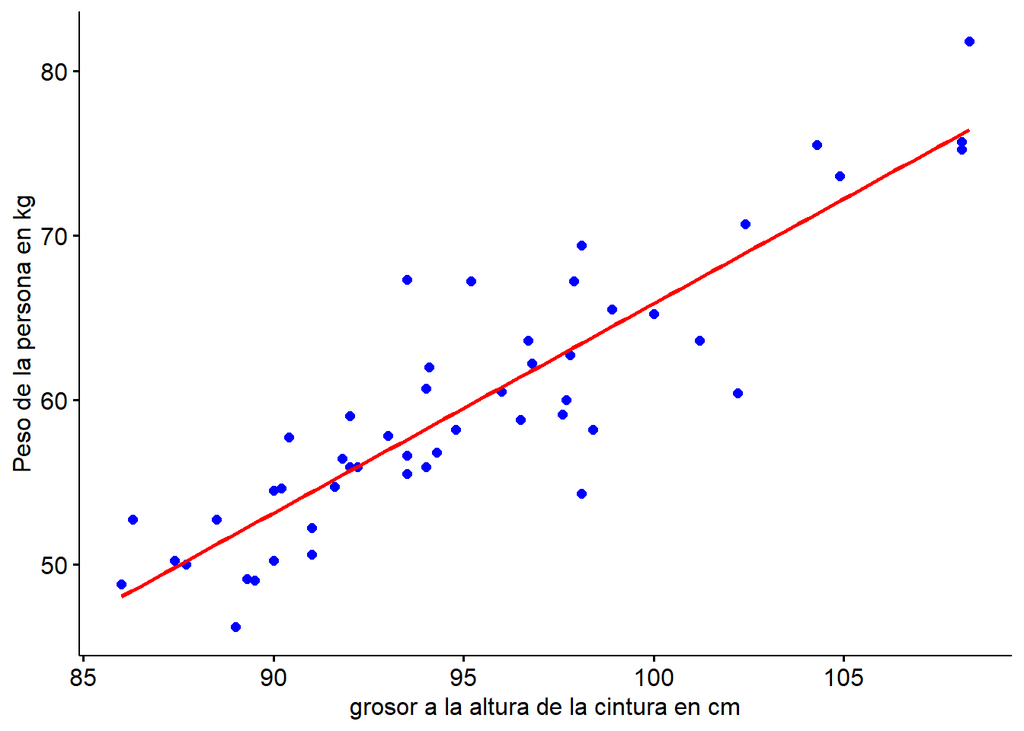

```r
# Paso 3: Gráfico del modelo

# Graficar el modelo
p <- ggscatter(muestra_m, x = "Hip.Girth", y = "Weight", color = "blue", fill = "orange" ,xlab = "grosor a la altura de la cintura en cm" , ylab = "Peso de la persona en kg",
               xticks.by = 5)

p <- p + geom_smooth(method = lm, se = FALSE, colour = "red" )
print(p)
```